# Biostat 212a Homework 1

Due Jan 23, 2024 @ 11:59PM

Author

Brilla Meng UID: 806329681

Published

January 23, 2024

## 1 Filling gaps in lecture notes (10pts)

Consider the regression model
$$Y = f(X) + \epsilon,$$
where $\operatorname{E}(\epsilon) = 0$.

### 1.1 Optimal regression function

Show that the choice
$$f_{\text{opt}}(X) = \operatorname{E}(Y | X)$$
minimizes the mean squared prediction error
$$\operatorname{E}\{[Y - f(X)]^2\},$$
where the expectations averages over variations in both $X$ and $Y$. (Hint: condition on $X$.)

**answer**:
$$\operatorname{E}\{[Y - f(X)]^2|X=x\} \\
=\operatorname{E}[Y^2|X=x] - 2f(X)\operatorname{E}[Y|X=x]+f(x)^2 \\$$
taking derivative with respect to f(x)
$$-2\operatorname{E}[Y|X=x]+2f(x)=0 \\
2f(x)=2\operatorname{E}[Y|X=x] \\
f(x)=\operatorname{E}[Y|X=x]$$
Therefore, we found E[Y|X=x] is the minimizes the MSE.

### 1.2 Bias-variance trade-off

Given an estimate $\hat f$ of $f$, show that the test error at a $x_0$ can be decomposed as
$$\operatorname{E}\{[y_0 - \hat f(x_0)]^2\} = \underbrace{\operatorname{Var}(\hat f(x_0)) + [\operatorname{Bias}(\hat f(x_0))]^2}_{\text{MSE of } \hat f(x_0) \text{ for estimating } f(x_0)} + \underbrace{\operatorname{Var}(\epsilon)}_{\text{irreducible}},$$
where the expectation averages over the variability in $y_0$ and $\hat f$.

**answer**:
$$\operatorname{E}\{[y_0 - \hat f(x_0)]^2\} \\
=\operatorname{E}\{[y_0 - f(x_0) + f(x_0) - \hat f(x_0)]^2\} \\
=\operatorname{E}\{[y_0 - f(x_0)]^2\} + \operatorname{E}\{[f(x_0) - \hat f(x_0)]^2\} + 2\operatorname{E}\{[y_0 - f(x_0)][f(x_0) - \hat f(x_0)]\} \\$$
Since E[$\epsilon$] = 0 and Y0 = f(x0) + $\epsilon$ ,we have
$$\operatorname{E}\{[y_0 - f(x_0)]^2\} \\
=\operatorname{E}\{[f(x_0) + \epsilon - f(x_0)]^2\} \\
=\operatorname{E}\{[\epsilon]^2\} - (\operatorname{E}[\epsilon])^2 +(E[\epsilon])^2 \\
=\operatorname{Var}(\epsilon) \\$$
Since Y0-f(x0) = $\epsilon$, E[$\epsilon$] = 0
$$2(f(x_0) - \hat f(x_0))\operatorname{E}\{[y_0 - f(x_0)]\} \\
=2(f(x_0) - \hat f(x_0))\operatorname{E}\{[\epsilon]\} \\
=0\\
\operatorname{E}\{[y_0 - \hat f(x_0)]^2\} \\
=\operatorname{E}[(f(x_0) - \hat f(x_0))^2] + \operatorname{E}(\hat f(x_0))-\hat f(x_0)^2 \\
=\operatorname{E}[f(x_0)-E[\hat f(x_0)]]^2 + E[\hat f(x_0)]-\hat f(x_0)]]^2 \\
=Bias^2[\hat f(x_0)] + Var[\hat f(x_0)]$$
Combine all of them, we can got:
$$\operatorname{E}\{[y_0 - \hat f(x_0)]^2\} = Var(\hat f(x_0)) + Bias^2(\hat f(x_0)) + Var(\epsilon)$$

## 2 ISL Exercise 2.4.3 (10pts)

```r
library(tidyverse)
flexibility <- seq(1, 10, length.out = 100)

bias_squared <- (10 - flexibility)^2 / 100
variance <- flexibility^2 / 100
training_error <- bias_squared - (flexibility / 50) + 0.2
irreducible_error <- rep(0.2, length(flexibility))
test_error <- bias_squared + variance + irreducible_error


data <- data.frame(flexibility, bias_squared, variance, training_error, test_error, irreducible_error)


library(reshape2)
data_melted <- melt(data, id.vars = 'flexibility')

ggplot(data_melted, aes(x = flexibility, y = value, color = variable)) +
  geom_line() +
  labs(x = 'Flexibility', y = 'Error', title = 'Bias-Variance Decomposition') +
  theme_minimal() +
  scale_color_discrete(name = "Curves", labels = c("Squared Bias", "Variance", "Training Error",
                                                   "Test Error", "Bayes (Irreducible) Error"))
```

[output not shown]

2. Test error decreases initially but rises as flexibility leads to overfitting.Test error decreases initially but rises as flexibility leads to overfitting. Bias decreases, improving problem representation, while variance increases, especially at higher flexibility, reducing model robustness. This highlights the challenge in balancing model complexity for optimal performance.

## 3 ISL Exercise 2.4.4 (10pts)

1. Medical Diagnosis: Response: Diagnosis (e.g., disease present or not). Predictors: Patient symptoms, lab test results, demographic data (age, gender), medical history. Goal: The goal is primarily prediction. The emphasis is on accurately predicting whether a patient has a specific disease or condition based on their symptoms and test results. While inference can be valuable for understanding which factors are most predictive of certain diseases, the immediate utility is in the accurate and efficient prediction of the disease for treatment decisions.
2. Credit Scoring in Finance: Response: Creditworthiness (e.g., high or low credit risk). Predictors: Credit history, current debts, income, employment status, past loan repayment history, credit score. Goal: This application leans towards prediction. Financial institutions use these models to predict the likelihood that an individual will repay a loan. Understanding the factors that influence credit risk is important, but the primary objective is to predict an individual’s credit risk to make lending decisions.
3. Customer Churn Prediction in Business: Response: Churn (e.g., whether a customer will stop using a company’s products/services). Predictors: Customer interaction history, purchase history, customer service records, demographic data, usage patterns. Goal: Again, the goal is prediction. Companies use these models to predict which customers are at risk of leaving so that they can take proactive measures to retain them. While inference might help understand why customers churn, the direct aim is to predict churn to implement retention strategies.
1. Real Estate Pricing: Response: House price. Predictors: Size (square footage), location, number of bedrooms, age of the house, proximity to amenities, etc. Goal: This application is primarily for prediction. The focus is on predicting the price of a house based on various features, which is crucial for buyers, sellers, and real estate agents.
2. Weather Forecasting: Response: Temperature. Predictors: Humidity, atmospheric pressure, wind speed, historical temperature data, time of the year, etc. Goal: The goal is prediction. Accurate temperature forecasts based on current and historical weather data are vital for a range of activities, from agriculture to daily planning.
3. Educational Outcomes: Response: Student academic performance (e.g., grades or test scores). Predictors: Study hours, attendance, parental education level, socioeconomic status, previous academic records, etc. Goal: This can be for both inference and prediction. While predicting student performance is valuable, understanding the impact of various factors (like study hours or socioeconomic status) on academic outcomes is also crucial for educational policy and interventions.
1. Market Segmentation: Objective: To categorize customers into different segments based on their purchasing behavior, preferences, demographic characteristics, etc. Application: Companies can use cluster analysis to identify distinct groups within their customer base. This helps in tailoring marketing strategies, developing targeted products, and improving customer service by understanding the specific needs and preferences of each segment.
2. Genomic Data Classification in Biology: Objective: To classify genetic data for identifying patterns and similarities in DNA sequences. Application: In biological research, cluster analysis is employed to group genes with similar expression patterns, which can be indicative of shared functions or regulatory mechanisms. This is crucial in understanding genetic diseases, evolutionary biology, and the development of targeted treatments.
3. Document Classification: Objective: To organize and categorize large sets of digital documents based on their content and thematic similarities. Application: This is particularly useful in digital libraries, online research databases, and for information retrieval systems. By clustering documents, these systems can enhance search accuracy, improve the organization of information, and enable users to discover related content more effectively.

## 4 ISL Exercise 2.4.10 (30pts)

Your can read in the `boston` data set directly from url https://raw.githubusercontent.com/ucla-biostat-212a/2024winter/master/slides/data/Boston.csv. A documentation of the `boston` data set is [here](https://www.rdocumentation.org/packages/ISLR2/versions/1.3-2/topics/Boston).

#### 4.0.1 R

```r
library(tidyverse)

Boston <- read_csv("https://raw.githubusercontent.com/ucla-biostat-212a/2024winter/master/slides/data/Boston.csv", col_select = -1) %>%
  print(width = Inf)
```

```
# A tibble: 506 × 13
      crim    zn indus  chas   nox    rm   age   dis   rad   tax ptratio lstat
     <dbl> <dbl> <dbl> <dbl> <dbl> <dbl> <dbl> <dbl> <dbl> <dbl>   <dbl> <dbl>
 1 0.00632  18    2.31     0 0.538  6.58  65.2  4.09     1   296    15.3  4.98
 2 0.0273    0    7.07     0 0.469  6.42  78.9  4.97     2   242    17.8  9.14
 3 0.0273    0    7.07     0 0.469  7.18  61.1  4.97     2   242    17.8  4.03
 4 0.0324    0    2.18     0 0.458  7.00  45.8  6.06     3   222    18.7  2.94
 5 0.0690    0    2.18     0 0.458  7.15  54.2  6.06     3   222    18.7  5.33
 6 0.0298    0    2.18     0 0.458  6.43  58.7  6.06     3   222    18.7  5.21
 7 0.0883   12.5  7.87     0 0.524  6.01  66.6  5.56     5   311    15.2 12.4
 8 0.145    12.5  7.87     0 0.524  6.17  96.1  5.95     5   311    15.2 19.2
 9 0.211    12.5  7.87     0 0.524  5.63 100    6.08     5   311    15.2 29.9
10 0.170    12.5  7.87     0 0.524  6.00  85.9  6.59     5   311    15.2 17.1
    medv
   <dbl>
 1  24
 2  21.6
 3  34.7
 4  33.4
 5  36.2
 6  28.7
 7  22.9
 8  27.1
 9  16.5
10  18.9
# ℹ 496 more rows
```

**answer**: There is 506 rows and 13 columns in the data set. Each row represent the set of predictor obeservations for a given Neighborhood in Boston. Each column represent each predictor variable for which an observation was made in 506 neighborhoods of Boston.

```r
str(Boston)
```

```
tibble [506 × 13] (S3: tbl_df/tbl/data.frame)
 $ crim   : num [1:506] 0.00632 0.02731 0.02729 0.03237 0.06905 ...
 $ zn     : num [1:506] 18 0 0 0 0 0 12.5 12.5 12.5 12.5 ...
 $ indus  : num [1:506] 2.31 7.07 7.07 2.18 2.18 2.18 7.87 7.87 7.87 7.87 ...
 $ chas   : num [1:506] 0 0 0 0 0 0 0 0 0 0 ...
 $ nox    : num [1:506] 0.538 0.469 0.469 0.458 0.458 0.458 0.524 0.524 0.524 0.524 ...
 $ rm     : num [1:506] 6.58 6.42 7.18 7 7.15 ...
 $ age    : num [1:506] 65.2 78.9 61.1 45.8 54.2 58.7 66.6 96.1 100 85.9 ...
 $ dis    : num [1:506] 4.09 4.97 4.97 6.06 6.06 ...
 $ rad    : num [1:506] 1 2 2 3 3 3 5 5 5 5 ...
 $ tax    : num [1:506] 296 242 242 222 222 222 311 311 311 311 ...
 $ ptratio: num [1:506] 15.3 17.8 17.8 18.7 18.7 18.7 15.2 15.2 15.2 15.2 ...
 $ lstat  : num [1:506] 4.98 9.14 4.03 2.94 5.33 ...
 $ medv   : num [1:506] 24 21.6 34.7 33.4 36.2 28.7 22.9 27.1 16.5 18.9 ...
 - attr(*, "spec")=
  .. cols(
  ..   ...1 = col_skip(),
  ..   crim = col_double(),
  ..   zn = col_double(),
  ..   indus = col_double(),
  ..   chas = col_double(),
  ..   nox = col_double(),
  ..   rm = col_double(),
  ..   age = col_double(),
  ..   dis = col_double(),
  ..   rad = col_double(),
  ..   tax = col_double(),
  ..   ptratio = col_double(),
  ..   lstat = col_double(),
  ..   medv = col_double()
  .. )
```

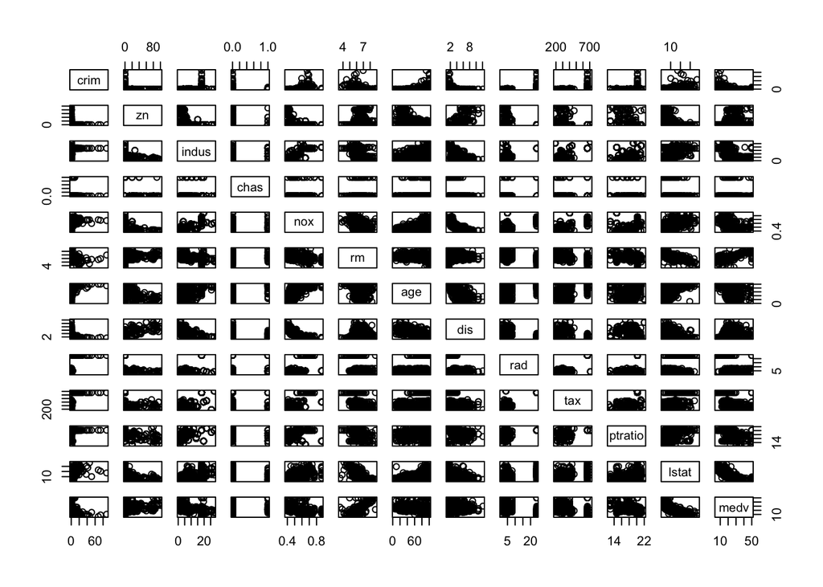

```r
Boston$chas <- as.numeric(Boston$chas)
Boston$rad <- as.numeric(Boston$rad)
pairs(Boston)
```

**answer**: Not much can be discerned other than the fact that some variables appear to be correlated.

```r
cor(Boston)
```

```
               crim          zn       indus         chas         nox
crim     1.00000000 -0.20046922  0.40658341 -0.055891582  0.42097171
zn      -0.20046922  1.00000000 -0.53382819 -0.042696719 -0.51660371
indus    0.40658341 -0.53382819  1.00000000  0.062938027  0.76365145
chas    -0.05589158 -0.04269672  0.06293803  1.000000000  0.09120281
nox      0.42097171 -0.51660371  0.76365145  0.091202807  1.00000000
rm      -0.21924670  0.31199059 -0.39167585  0.091251225 -0.30218819
age      0.35273425 -0.56953734  0.64477851  0.086517774  0.73147010
dis     -0.37967009  0.66440822 -0.70802699 -0.099175780 -0.76923011
rad      0.62550515 -0.31194783  0.59512927 -0.007368241  0.61144056
tax      0.58276431 -0.31456332  0.72076018 -0.035586518  0.66802320
ptratio  0.28994558 -0.39167855  0.38324756 -0.121515174  0.18893268
lstat    0.45562148 -0.41299457  0.60379972 -0.053929298  0.59087892
medv    -0.38830461  0.36044534 -0.48372516  0.175260177 -0.42732077
                 rm         age         dis          rad         tax    ptratio
crim    -0.21924670  0.35273425 -0.37967009  0.625505145  0.58276431  0.2899456
zn       0.31199059 -0.56953734  0.66440822 -0.311947826 -0.31456332 -0.3916785
indus   -0.39167585  0.64477851 -0.70802699  0.595129275  0.72076018  0.3832476
chas     0.09125123  0.08651777 -0.09917578 -0.007368241 -0.03558652 -0.1215152
nox     -0.30218819  0.73147010 -0.76923011  0.611440563  0.66802320  0.1889327
rm       1.00000000 -0.24026493  0.20524621 -0.209846668 -0.29204783 -0.3555015
age     -0.24026493  1.00000000 -0.74788054  0.456022452  0.50645559  0.2615150
dis      0.20524621 -0.74788054  1.00000000 -0.494587930 -0.53443158 -0.2324705
rad     -0.20984667  0.45602245 -0.49458793  1.000000000  0.91022819  0.4647412
tax     -0.29204783  0.50645559 -0.53443158  0.910228189  1.00000000  0.4608530
ptratio -0.35550149  0.26151501 -0.23247054  0.464741179  0.46085304  1.0000000
lstat   -0.61380827  0.60233853 -0.49699583  0.488676335  0.54399341  0.3740443
medv     0.69535995 -0.37695457  0.24992873 -0.381626231 -0.46853593 -0.5077867
             lstat       medv
crim     0.4556215 -0.3883046
zn      -0.4129946  0.3604453
indus    0.6037997 -0.4837252
chas    -0.0539293  0.1752602
nox      0.5908789 -0.4273208
rm      -0.6138083  0.6953599
age      0.6023385 -0.3769546
dis     -0.4969958  0.2499287
rad      0.4886763 -0.3816262
tax      0.5439934 -0.4685359
ptratio  0.3740443 -0.5077867
lstat    1.0000000 -0.7376627
medv    -0.7376627  1.0000000
```

```r
summary(Boston$crim)
```

```
    Min.  1st Qu.   Median     Mean  3rd Qu.     Max.
 0.00632  0.08204  0.25651  3.61352  3.67708 88.97620
```

```r
summary(Boston$tax)
```

```
   Min. 1st Qu.  Median    Mean 3rd Qu.    Max.
  187.0   279.0   330.0   408.2   666.0   711.0
```

```r
summary(Boston$ptratio)
```

```
   Min. 1st Qu.  Median    Mean 3rd Qu.    Max.
  12.60   17.40   19.05   18.46   20.20   22.00
```

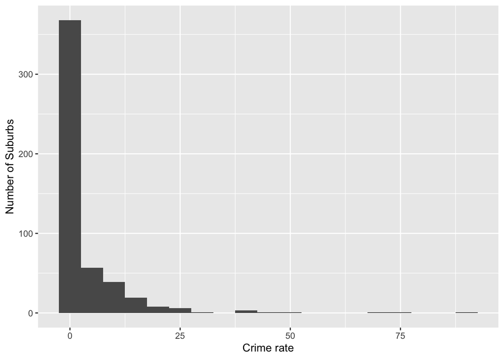

```r
qplot(Boston$crim, binwidth=5 , xlab = "Crime rate", ylab="Number of Suburbs" )
```

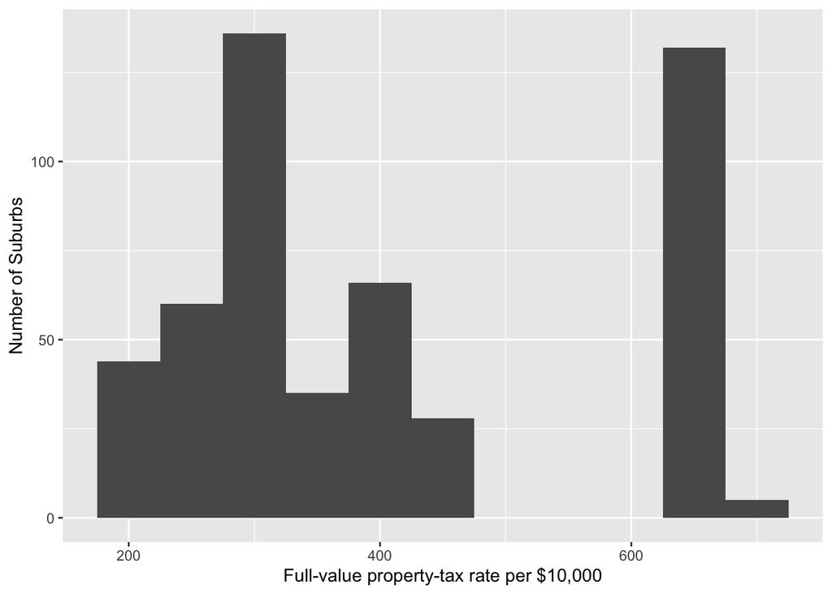

```r
qplot(Boston$tax, binwidth=50 , xlab = "Full-value property-tax rate per $10,000", ylab="Number of Suburbs")
```

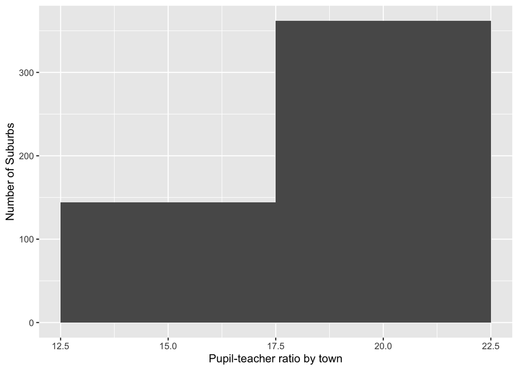

```r
qplot(Boston$ptratio, binwidth=5, xlab ="Pupil-teacher ratio by town", ylab="Number of Suburbs")
```

```r
selection <- subset( Boston, crim > 10)
nrow(selection)/ nrow(Boston)
```

```
[1] 0.1067194
```

```r
selection <- subset( Boston, crim > 60)
nrow(selection)/ nrow(Boston)
```

```
[1] 0.005928854
```

```r
selection <- subset( Boston, tax > 600)
nrow(selection)/ nrow(Boston)
```

```
[1] 0.270751
```

```r
selection <- subset( Boston, tax < 600)
nrow(selection)/ nrow(Boston)
```

```
[1] 0.729249
```

```r
selection <- subset( Boston, ptratio > 17.5)
nrow(selection)/ nrow(Boston)
```

```
[1] 0.715415
```

```r
selection <- subset( Boston, ptratio < 17.5)
nrow(selection)/ nrow(Boston)
```

```
[1] 0.284585
```

```r
nrow(subset(Boston, chas ==1))
```

```
[1] 35
```

**answer**: There are 35 census tracts that bound the Charles River.

```r
summary(Boston$ptratio)
```

```
   Min. 1st Qu.  Median    Mean 3rd Qu.    Max.
  12.60   17.40   19.05   18.46   20.20   22.00
```

**answer**: The median pupil-teacher ratio among the towns in this data set is 19.05.

```r
selection <- Boston[order(Boston$medv),]
selection[1,]
```

```
# A tibble: 1 × 13
   crim    zn indus  chas   nox    rm   age   dis   rad   tax ptratio lstat
  <dbl> <dbl> <dbl> <dbl> <dbl> <dbl> <dbl> <dbl> <dbl> <dbl>   <dbl> <dbl>
1  38.4     0  18.1     0 0.693  5.45   100  1.49    24   666    20.2  30.6
# ℹ 1 more variable: medv <dbl>
```

```r
summary(selection)
```

```
      crim                zn             indus            chas
 Min.   : 0.00632   Min.   :  0.00   Min.   : 0.46   Min.   :0.00000
 1st Qu.: 0.08205   1st Qu.:  0.00   1st Qu.: 5.19   1st Qu.:0.00000
 Median : 0.25651   Median :  0.00   Median : 9.69   Median :0.00000
 Mean   : 3.61352   Mean   : 11.36   Mean   :11.14   Mean   :0.06917
 3rd Qu.: 3.67708   3rd Qu.: 12.50   3rd Qu.:18.10   3rd Qu.:0.00000
 Max.   :88.97620   Max.   :100.00   Max.   :27.74   Max.   :1.00000
      nox               rm             age              dis
 Min.   :0.3850   Min.   :3.561   Min.   :  2.90   Min.   : 1.130
 1st Qu.:0.4490   1st Qu.:5.886   1st Qu.: 45.02   1st Qu.: 2.100
 Median :0.5380   Median :6.208   Median : 77.50   Median : 3.207
 Mean   :0.5547   Mean   :6.285   Mean   : 68.57   Mean   : 3.795
 3rd Qu.:0.6240   3rd Qu.:6.623   3rd Qu.: 94.08   3rd Qu.: 5.188
 Max.   :0.8710   Max.   :8.780   Max.   :100.00   Max.   :12.127
      rad              tax           ptratio          lstat
 Min.   : 1.000   Min.   :187.0   Min.   :12.60   Min.   : 1.73
 1st Qu.: 4.000   1st Qu.:279.0   1st Qu.:17.40   1st Qu.: 6.95
 Median : 5.000   Median :330.0   Median :19.05   Median :11.36
 Mean   : 9.549   Mean   :408.2   Mean   :18.46   Mean   :12.65
 3rd Qu.:24.000   3rd Qu.:666.0   3rd Qu.:20.20   3rd Qu.:16.95
 Max.   :24.000   Max.   :711.0   Max.   :22.00   Max.   :37.97
      medv
 Min.   : 5.00
 1st Qu.:17.02
 Median :21.20
 Mean   :22.53
 3rd Qu.:25.00
 Max.   :50.00
```

```r
rm_over_7 <- subset(Boston, rm>7)
nrow(rm_over_7)
```

```
[1] 64
```

```r
rm_over_8 <- subset(Boston, rm>8)
nrow(rm_over_8)
```

```
[1] 13
```

```r
summary(rm_over_8)
```

```
      crim               zn            indus             chas
 Min.   :0.02009   Min.   : 0.00   Min.   : 2.680   Min.   :0.0000
 1st Qu.:0.33147   1st Qu.: 0.00   1st Qu.: 3.970   1st Qu.:0.0000
 Median :0.52014   Median : 0.00   Median : 6.200   Median :0.0000
 Mean   :0.71879   Mean   :13.62   Mean   : 7.078   Mean   :0.1538
 3rd Qu.:0.57834   3rd Qu.:20.00   3rd Qu.: 6.200   3rd Qu.:0.0000
 Max.   :3.47428   Max.   :95.00   Max.   :19.580   Max.   :1.0000
      nox               rm             age             dis
 Min.   :0.4161   Min.   :8.034   Min.   : 8.40   Min.   :1.801
 1st Qu.:0.5040   1st Qu.:8.247   1st Qu.:70.40   1st Qu.:2.288
 Median :0.5070   Median :8.297   Median :78.30   Median :2.894
 Mean   :0.5392   Mean   :8.349   Mean   :71.54   Mean   :3.430
 3rd Qu.:0.6050   3rd Qu.:8.398   3rd Qu.:86.50   3rd Qu.:3.652
 Max.   :0.7180   Max.   :8.780   Max.   :93.90   Max.   :8.907
      rad              tax           ptratio          lstat           medv
 Min.   : 2.000   Min.   :224.0   Min.   :13.00   Min.   :2.47   Min.   :21.9
 1st Qu.: 5.000   1st Qu.:264.0   1st Qu.:14.70   1st Qu.:3.32   1st Qu.:41.7
 Median : 7.000   Median :307.0   Median :17.40   Median :4.14   Median :48.3
 Mean   : 7.462   Mean   :325.1   Mean   :16.36   Mean   :4.31   Mean   :44.2
 3rd Qu.: 8.000   3rd Qu.:307.0   3rd Qu.:17.40   3rd Qu.:5.12   3rd Qu.:50.0
 Max.   :24.000   Max.   :666.0   Max.   :20.20   Max.   :7.44   Max.   :50.0
```

## 5 ISL Exercise 3.7.3 (12pts)

## 6 ISL Exercise 3.7.15 (20pts)

## 7 Bonus question (20pts)

For multiple linear regression, show that $R^2$ is equal to the correlation between the response vector $\mathbf{y} = (y_1, \ldots, y_n)^T$ and the fitted values $\hat{\mathbf{y}} = (\hat y_1, \ldots, \hat y_n)^T$. That is
$$R^2 = 1 - \frac{\text{RSS}}{\text{TSS}} = [\operatorname{Cor}(\mathbf{y}, \hat{\mathbf{y}})]^2.$$